# CEMA _TASK.Rmd

THOMAS MABELE MASIBO

2023-07-19

You have been provided with a dataset (in the data folder above) which contains monthly data for children <5 years, disaggregated at a county level for the period January 2021 to June 2023.

The dataset contains the following varibales:

Period (months from January 2021 to June 2023) County (the 47 counties in Kenya) Total number of children dewormed (Total Dewormed) Number of children <5 years with acute malnutrition (Acute Malnutrition) Number of children stunted (0-6 months, 6-23 months, 24-59 months) Number of children <5 years with diarrhe (Diarrhea cases) Number of children who are underweight (0-6 months, 6-23 months, 24-59 months) Your task is to: – Conduct exploratory data analysis State an appropriate research question you would want to answer from the data Carry out appropriate data analysis to address the question you have stated above NB: The task should be carried out as an RMarkdown [refer to the notes shared earlier]

The roadmap I will use to approach this task.

1.Conduct exploratory data analysis and cleansing.

2.Carry out data analysis to address this research question; “What are the trends and patterns of acute malnutrition among children under 5 years across different counties in Kenya from January 2021 to June 2023?” 3. Interpretation and Conclusion.

### 1. Exploratory data analysis.

```r
#libraries needed
suppressPackageStartupMessages(library(tidyverse))
suppressPackageStartupMessages(library(corrplot))
suppressPackageStartupMessages(library(kableExtra))
suppressPackageStartupMessages(library(dplyr))
library(tidyverse)
library(ggplot2)
library(dplyr)
library(lubridate)
library(skimr)
library(knitr)
library(kableExtra)
library(corrplot)
```

a.Load the Dataset.

```r
csv_url<-"https://raw.githubusercontent.com/cema-uonbi/internship_task/main/data/cema_internship_task_2023.csv"
data<- readr::read_csv(csv_url,show_col_types = FALSE)
```

glimpse of the data

```r
head(data)
```

```
## # A tibble: 6 × 11
##   period county      `Total Dewormed` `Acute Malnutrition` `stunted 6-23 months`
##   <chr>  <chr>                  <dbl>                <dbl>                 <dbl>
## 1 Jan-23 Baringo Co…             3659                    8                   471
## 2 Jan-23 Bomet Coun…             1580                   NA                     1
## 3 Jan-23 Bungoma Co…             6590                   24                    98
## 4 Jan-23 Busia Coun…             7564                   NA                   396
## 5 Jan-23 Elgeyo Mar…             1407                   NA                    92
## 6 Jan-23 Embu County             3241                   72                   326
## # ℹ 6 more variables: `stunted 0-<6 months` <dbl>,
## #   `stunted 24-59 months` <dbl>, `diarrhoea cases` <dbl>,
## #   `Underweight 0-<6 months` <dbl>, `Underweight 6-23 months` <dbl>,
## #   `Underweight 24-59 Months` <dbl>
```

#We can observe that the data is imported as a tibble, and contains 1410 observations (rows) and 11 variables (columns).

b.Data Examination, structure of the data.

```r
# Display the data structure using skim()
skim(data)
```

Data summary

| Name | data |
| --- | --- |
| Number of rows | 1410 |
| Number of columns | 11 |
| _______________________ |  |
| Column type frequency: |  |
| character | 2 |
| numeric | 9 |
| ________________________ |  |
| Group variables | None |

**Variable type: character**

| skim_variable | n_missing | complete_rate | min | max | empty | n_unique | whitespace |
| --- | --- | --- | --- | --- | --- | --- | --- |
| period | 0 | 1 | 6 | 6 | 0 | 30 | 0 |
| county | 0 | 1 | 11 | 22 | 0 | 47 | 0 |

**Variable type: numeric**

| skim_variable | n_missing | complete_rate | mean | sd | p0 | p25 | p50 | p75 | p100 | hist |
| --- | --- | --- | --- | --- | --- | --- | --- | --- | --- | --- |
| Total Dewormed | 0 | 1.00 | 11457.92 | 25372.43 | 97 | 2454.50 | 4564.5 | 8222.50 | 392800 | ▇▁▁▁▁ |
| Acute Malnutrition | 355 | 0.75 | 125.40 | 266.49 | 1 | 15.00 | 39.0 | 143.50 | 4123 | ▇▁▁▁▁ |
| stunted 6-23 months | 11 | 0.99 | 280.16 | 380.55 | 1 | 69.50 | 159.0 | 328.50 | 4398 | ▇▁▁▁▁ |
| stunted 0-<6 months | 19 | 0.99 | 139.79 | 280.24 | 1 | 36.50 | 84.0 | 157.00 | 7900 | ▇▁▁▁▁ |
| stunted 24-59 months | 14 | 0.99 | 110.77 | 193.40 | 1 | 22.00 | 50.0 | 114.25 | 3169 | ▇▁▁▁▁ |
| diarrhoea cases | 0 | 1.00 | 2813.38 | 2161.90 | 198 | 1464.25 | 2158.0 | 3335.25 | 15795 | ▇▂▁▁▁ |
| Underweight 0-<6 months | 0 | 1.00 | 223.47 | 228.53 | 6 | 87.00 | 162.5 | 272.75 | 1937 | ▇▁▁▁▁ |
| Underweight 6-23 months | 0 | 1.00 | 652.26 | 669.58 | 16 | 249.00 | 456.0 | 791.75 | 5348 | ▇▁▁▁▁ |
| Underweight 24-59 Months | 0 | 1.00 | 305.74 | 538.46 | 1 | 51.25 | 120.5 | 311.00 | 4680 | ▇▁▁▁▁ |

-the datatypes are numeric unlike the county and period columns. - some data has missing values eg the Acute Malnutrition column. - the data is fairly clean with few inconsistencies.

Summary Statistics for all the variables.

```r
summary_stats= summary(data)
```

Summary Statistics in a table representation

```r
kable(summary_stats, caption = "Summary Statistics of the Dataset") %>%
  kable_styling(full_width = 1000)
```

Summary Statistics of the Dataset

|  | period | county | Total Dewormed | Acute Malnutrition | stunted 6-23 months | stunted 0-<6 months | stunted 24-59 months | diarrhoea cases | Underweight 0-<6 months | Underweight 6-23 months | Underweight 24-59 Months |
| --- | --- | --- | --- | --- | --- | --- | --- | --- | --- | --- | --- |
|  | Length:1410 | Length:1410 | Min. : 97 | Min. : 1.0 | Min. : 1.0 | Min. : 1.0 | Min. : 1.0 | Min. : 198 | Min. : 6.0 | Min. : 16.0 | Min. : 1.00 |
|  | Class :character | Class :character | 1st Qu.: 2454 | 1st Qu.: 15.0 | 1st Qu.: 69.5 | 1st Qu.: 36.5 | 1st Qu.: 22.0 | 1st Qu.: 1464 | 1st Qu.: 87.0 | 1st Qu.: 249.0 | 1st Qu.: 51.25 |
|  | Mode :character | Mode :character | Median : 4564 | Median : 39.0 | Median : 159.0 | Median : 84.0 | Median : 50.0 | Median : 2158 | Median : 162.5 | Median : 456.0 | Median : 120.50 |
|  | NA | NA | Mean : 11458 | Mean : 125.4 | Mean : 280.2 | Mean : 139.8 | Mean : 110.8 | Mean : 2813 | Mean : 223.5 | Mean : 652.3 | Mean : 305.74 |
|  | NA | NA | 3rd Qu.: 8222 | 3rd Qu.: 143.5 | 3rd Qu.: 328.5 | 3rd Qu.: 157.0 | 3rd Qu.: 114.2 | 3rd Qu.: 3335 | 3rd Qu.: 272.8 | 3rd Qu.: 791.8 | 3rd Qu.: 311.00 |
|  | NA | NA | Max. :392800 | Max. :4123.0 | Max. :4398.0 | Max. :7900.0 | Max. :3169.0 | Max. :15795 | Max. :1937.0 | Max. :5348.0 | Max. :4680.00 |
|  | NA | NA | NA | NA’s :355 | NA’s :11 | NA’s :19 | NA’s :14 | NA | NA | NA | NA |

Descriptive statistics

c.Data Cleaning.

-Here we shall remove Na values by mean imputation, Check the duplicates, Change period column datatype to date type for time series analysis.

-Dealing with missing values in data; graphical representation via a heatmap.

[figure not shown]

```r
missing_values <- is.na(data)

# Calculate the missingness matrix
missing_matrix <- is.na(data)

# Convert the missingness matrix to a data frame
missing_df <- data.frame(x = rep(1, ncol(missing_matrix)),
                         y = seq_len(nrow(missing_matrix)),
                         is_missing = c(missing_matrix))

# Create the missing values heatmap
ggplot(data = missing_df, aes(x = x, y = y, fill = is_missing)) +
  geom_tile() +
  scale_fill_manual(values = c("blue", "red"), labels = c("Non-missing", "Missing")) +
  coord_flip() +
  xlab("") +
  ylab("Observations") +
  ggtitle("Missing Values Heat Map")
```

From the graph above, the missing values in all the data frame are fewer, blue is the dominant color.

```r
 # Calculate the count of missing values per column
missing_counts <- colSums(is.na(data))

# Print the missing value counts
print(missing_counts)
```

```
##                   period                   county           Total Dewormed
##                        0                        0                        0
##       Acute Malnutrition      stunted 6-23 months      stunted 0-<6 months
##                      355                       11                       19
##     stunted 24-59 months          diarrhoea cases  Underweight 0-<6 months
##                       14                        0                        0
##  Underweight 6-23 months Underweight 24-59 Months
##                        0                        0
```

The acute mulnutrition column has more missing values, here is a histogram to help us see this pattern.

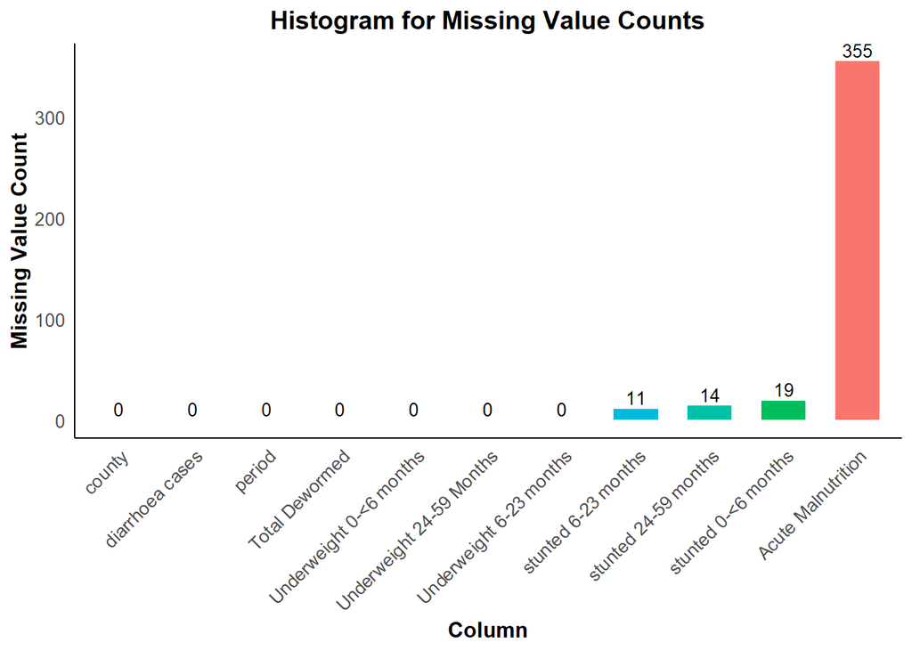

```r
# Calculate the count of missing values per column
missing_counts <- colSums(is.na(data))

# Convert the missing counts to a data frame
missing_df <- data.frame(column = names(missing_counts), count = missing_counts)

# Sort the data frame in ascending order
missing_df <- missing_df[order(missing_df$count), ]

# Create a histogram for missing value counts
ggplot(data = missing_df, aes(x = reorder(column, count), y = count, fill = column)) +
  geom_bar(stat = "identity", width = 0.6) +
  geom_text(aes(label = count), vjust = -0.3, color = "black", size = 3.5) +
  xlab("Column") +
  ylab("Missing Value Count") +
  ggtitle("Histogram for Missing Value Counts") +
  theme_minimal() +
  theme(axis.text.x = element_text(angle = 45, hjust = 1, size = 10),
        axis.text.y = element_text(size = 10),
        axis.title = element_text(size = 12, face = "bold"),
        plot.title = element_text(size = 14, face = "bold", hjust = 0.5),
        legend.position = "none",
        panel.grid.major = element_blank(),
        panel.grid.minor = element_blank(),
        panel.border = element_blank(),
        axis.line = element_line(color = "black"))
```

#Perfoming mean imputation on na values to remove them from the data frame.

```r
# Function to apply mean imputation to numeric columns
fill_na_with_mean <- function(x) {
  if (is.numeric(x)) {
    mean_val <- mean(x, na.rm = TRUE)
    replace(x, is.na(x), mean_val)
  } else {
    x
  }
}
# Fill NA values with mean for numeric columns
data_imputed <- data %>%
  mutate(across(where(is.numeric), fill_na_with_mean))

# Display the modified data frame
data=data_imputed
tail(data)
```

```
## # A tibble: 6 × 11
##   period county      `Total Dewormed` `Acute Malnutrition` `stunted 6-23 months`
##   <chr>  <chr>                  <dbl>                <dbl>                 <dbl>
## 1 Dec-21 Kwale Coun…             7193                  29                    372
## 2 Dec-21 Kitui Coun…            29802                   1                    226
## 3 Dec-21 Kisumu Cou…             5431                  26                    101
## 4 Dec-21 Kisii Coun…             2040                 125.                    40
## 5 Dec-21 Wajir Coun…            13522                 432                     66
## 6 Dec-21 West Pokot…             6970                  22                      5
## # ℹ 6 more variables: `stunted 0-<6 months` <dbl>,
## #   `stunted 24-59 months` <dbl>, `diarrhoea cases` <dbl>,
## #   `Underweight 0-<6 months` <dbl>, `Underweight 6-23 months` <dbl>,
## #   `Underweight 24-59 Months` <dbl>
```

To confirm all Na values are removed. All columns have zero Na values.

```r
missing_counts <- colSums(is.na(data))
print(missing_counts)
```

```
##                   period                   county           Total Dewormed
##                        0                        0                        0
##       Acute Malnutrition      stunted 6-23 months      stunted 0-<6 months
##                        0                        0                        0
##     stunted 24-59 months          diarrhoea cases  Underweight 0-<6 months
##                        0                        0                        0
##  Underweight 6-23 months Underweight 24-59 Months
##                        0                        0
```

Checking for duplicate values

```r
# Check for duplicates
has_duplicates <- any(duplicated(data))
print(has_duplicates)
```

```
## [1] FALSE
```

The dataset has no duplicate row for us to handle.

The new cleaned data saved as Data.

```r
Data = data
head(Data)
```

```
## # A tibble: 6 × 11
##   period county      `Total Dewormed` `Acute Malnutrition` `stunted 6-23 months`
##   <chr>  <chr>                  <dbl>                <dbl>                 <dbl>
## 1 Jan-23 Baringo Co…             3659                   8                    471
## 2 Jan-23 Bomet Coun…             1580                 125.                     1
## 3 Jan-23 Bungoma Co…             6590                  24                     98
## 4 Jan-23 Busia Coun…             7564                 125.                   396
## 5 Jan-23 Elgeyo Mar…             1407                 125.                    92
## 6 Jan-23 Embu County             3241                  72                    326
## # ℹ 6 more variables: `stunted 0-<6 months` <dbl>,
## #   `stunted 24-59 months` <dbl>, `diarrhoea cases` <dbl>,
## #   `Underweight 0-<6 months` <dbl>, `Underweight 6-23 months` <dbl>,
## #   `Underweight 24-59 Months` <dbl>
```

## 3.The research question.

# What are the trends and patterns of acute malnutrition among children under 5 years across different counties in Kenya from January 2021 to June 2023?

a.County level variations, the objective is to know the counties with high mulnutrition.

```r
filtered_data <- Data %>%
  select('county', `Acute Malnutrition`)
filtered_data
```

```
## # A tibble: 1,410 × 2
##    county                 `Acute Malnutrition`
##    <chr>                                 <dbl>
##  1 Baringo County                           8
##  2 Bomet County                           125.
##  3 Bungoma County                          24
##  4 Busia County                           125.
##  5 Elgeyo Marakwet County                 125.
##  6 Embu County                             72
##  7 Garissa County                         250
##  8 Homa Bay County                          9
##  9 Isiolo County                           26
## 10 Kajiado County                         104
## # ℹ 1,400 more rows
```

Graphical representation,Visualization Using a scatter plot to show acute mulnutrition per county:

```r
# Calculate county-level statistics
county_stats <- filtered_data %>%
  group_by(county) %>%
  summarise(mean_acute_malnutrition = mean(`Acute Malnutrition`),
            max_acute_malnutrition = max(`Acute Malnutrition`),
            min_acute_malnutrition = min(`Acute Malnutrition`))
```

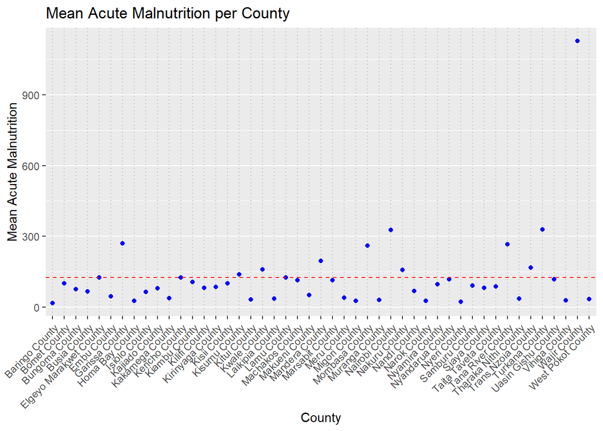

```r
# Create a scatter plot with grid lines and horizontal line for mean
ggplot(county_stats, aes(x = county, y = mean_acute_malnutrition)) +
  geom_point(color = "blue") +
  geom_hline(yintercept = mean(county_stats$mean_acute_malnutrition), linetype = "dashed", color = "red") +
  labs(title = "Mean Acute Malnutrition per County",
       x = "County",
       y = "Mean Acute Malnutrition") +
  theme(axis.text.x = element_text(angle = 45, hjust = 1)) +
  theme(panel.grid.major.x = element_line(color = "gray", linetype = "dotted")) +
  theme(panel.grid.minor.x = element_blank())
```

This scatter plot show the mean “Acute Malnutrition” per county, allowing us to identify counties with different levels of malnutrition.

Group data by ‘County’ and calculate the mean of ‘Acute Malnutrition’ for each county.

```r
# Group data by 'County' and calculate the mean of 'Acute Malnutrition' for each county.
mean_acute_malnutrition_by_county <- filtered_data %>%
  group_by(county) %>%
  summarise(mean_acute_malnutrition = mean(`Acute Malnutrition`, na.rm = TRUE))

# Arrange the data frame in descending order of mean_acute_malnutrition
mean_acute_malnutrition_by_county <- mean_acute_malnutrition_by_county %>%
  arrange(desc(mean_acute_malnutrition))

# View the resulting dataframe
print(mean_acute_malnutrition_by_county)
```

```
## # A tibble: 47 × 2
##    county             mean_acute_malnutrition
##    <chr>                                <dbl>
##  1 Wajir County                         1129.
##  2 Turkana County                        328.
##  3 Nairobi County                        327.
##  4 Garissa County                        269.
##  5 Tana River County                     265.
##  6 Mombasa County                        259.
##  7 Mandera County                        195.
##  8 Trans Nzoia County                    166.
##  9 Kwale County                          159.
## 10 Nakuru County                         157.
## # ℹ 37 more rows
```

A bar plot to visualize the results.

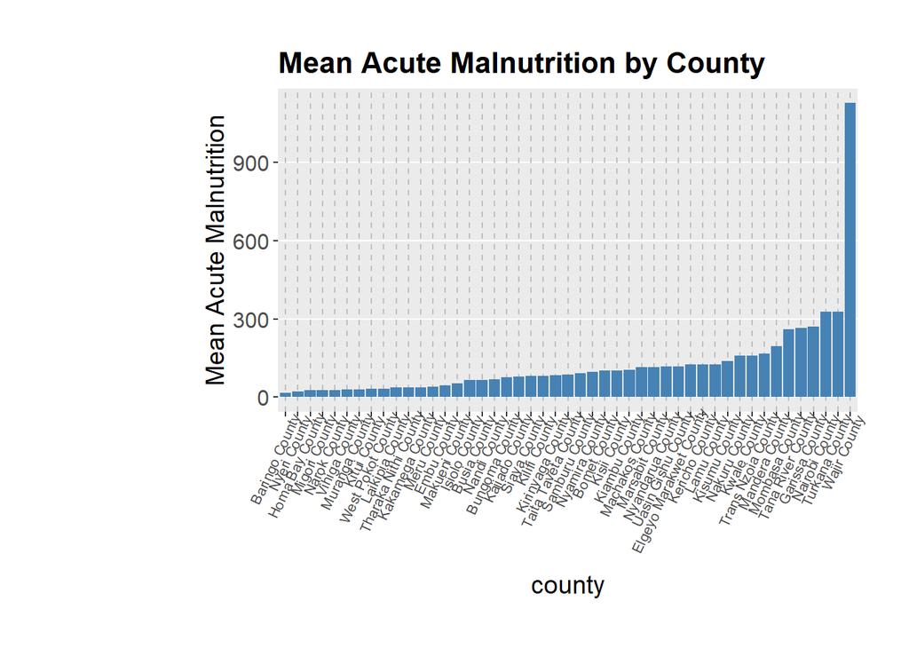

```r
# Group data by 'County' and calculate the mean of 'Acute Malnutrition' for each county
mean_acute_malnutrition_by_county <- data %>%
  group_by(county) %>%
  summarise(mean_acute_malnutrition = mean(`Acute Malnutrition`, na.rm = TRUE))

# Reorder counties in ascending order based on the mean of 'Acute Malnutrition'
mean_acute_malnutrition_by_county$county <- factor(mean_acute_malnutrition_by_county$county,
                                                  levels = mean_acute_malnutrition_by_county$county[order(mean_acute_malnutrition_by_county$mean_acute_malnutrition)])

# Increase the plot size and adjust axis text size
ggplot(mean_acute_malnutrition_by_county, aes(x = county, y = mean_acute_malnutrition)) +
  geom_bar(stat = "identity", fill = "steelblue") +
  xlab("county") +
  ylab("Mean Acute Malnutrition") +
  ggtitle("Mean Acute Malnutrition by County") +
  theme(axis.text.x = element_text(angle = 65, hjust = 0.9, size = 8),  # Rotate and adjust x-axis text size
        axis.text.y = element_text(size = 12),
        axis.title = element_text(size = 14),
        plot.title = element_text(size = 16, face = "bold"),
        panel.grid.major.x = element_line(color = "gray", linetype = "dashed"),
        panel.grid.minor = element_blank(),
        plot.margin = margin(1, 1, 1, 4, "cm"))
```

From the output above, Wajir has the highest number of acute mulnutritioned children with 1128.667 while baringo county has the lowest at 16.59.The dotted red line, gives the overall base mean which is 125.4 as shown in descriptive statistics below.

Conclusion, more health interventions are need for counties with high acute mulnutrion.

We calculate the summary statistics (mean, median, and standard deviation) of acute malnutrition cases to analyze the central tendency and variability of the data.

```r
# Calculate summary statistics
mean_acute_malnutrition <- mean(filtered_data$`Acute Malnutrition`, na.rm = TRUE)
median_acute_malnutrition <- median(filtered_data$`Acute Malnutrition`, na.rm = TRUE)
sd_acute_malnutrition <- sd(filtered_data$`Acute Malnutrition`, na.rm = TRUE)
```

```r
# Print the summary statistics
cat("Summary Statistics for Acute Malnutrition Cases:\n")
```

```
## Summary Statistics for Acute Malnutrition Cases:
```

```r
cat("Mean:", mean_acute_malnutrition, "\n")
```

```
## Mean: 125.4
```

```r
cat("Median:", median_acute_malnutrition, "\n")
```

```
## Median: 93
```

```r
cat("Standard Deviation:", sd_acute_malnutrition, "\n")
```

```
## Standard Deviation: 230.4856
```

#Visualization. Box plot of acute mulnutrition cases

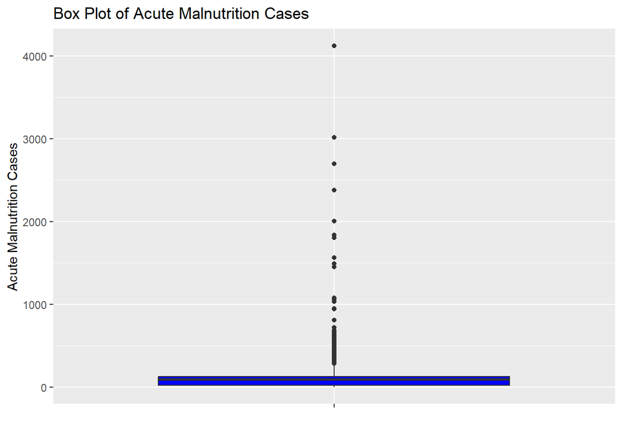

```r
# Determine the central tendency and variability of the data using a box plot
library(ggplot2)

ggplot(filtered_data, aes(x = "", y = `Acute Malnutrition`)) +
  geom_boxplot(fill = "blue") +
  labs(title = "Box Plot of Acute Malnutrition Cases",
       x = "",
       y = "Acute Malnutrition Cases")
```

```r
filtered_data1 <- Data %>%
  select('period','county', `Acute Malnutrition`)
filtered_data1=filtered_data1
head(filtered_data1)
```

```
## # A tibble: 6 × 3
##   period county                 `Acute Malnutrition`
##   <chr>  <chr>                                 <dbl>
## 1 Jan-23 Baringo County                           8
## 2 Jan-23 Bomet County                           125.
## 3 Jan-23 Bungoma County                          24
## 4 Jan-23 Busia County                           125.
## 5 Jan-23 Elgeyo Marakwet County                 125.
## 6 Jan-23 Embu County                             72
```

Changing the period column from char to date time so that we can perfom time series analysis.

```r
filtered_data1$period<- as.Date(paste0("01-", filtered_data1$period), format = "%d-%b-%y")
head(filtered_data1)
```

```
## # A tibble: 6 × 3
##   period     county                 `Acute Malnutrition`
##   <date>     <chr>                                 <dbl>
## 1 2023-01-01 Baringo County                           8
## 2 2023-01-01 Bomet County                           125.
## 3 2023-01-01 Bungoma County                          24
## 4 2023-01-01 Busia County                           125.
## 5 2023-01-01 Elgeyo Marakwet County                 125.
## 6 2023-01-01 Embu County                             72
```

B.Time series analysis. To visualize the trends in acute malnutrition over time, we’ll create a time series plot using R and the ggplot2 package.

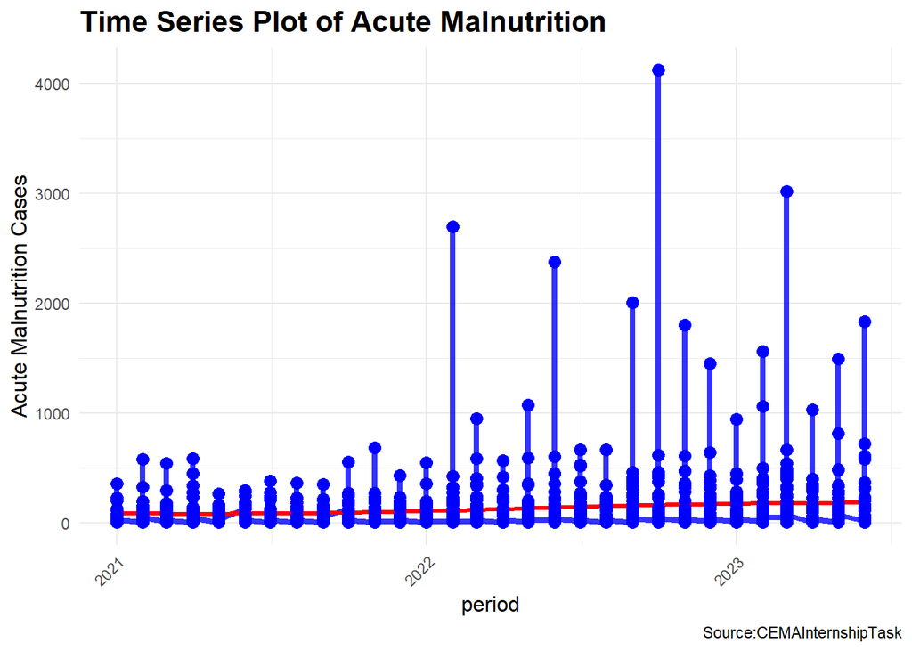

```r
# Create a time series plot with additional features
ggplot(filtered_data1, aes(x = period, y = `Acute Malnutrition`)) +
  geom_line(color = "blue", size = 1.5, alpha = 0.8) +
  geom_smooth(method = "loess", color = "red", size = 1.2, se = FALSE) +
  geom_point(color = "blue", size = 3) +
  labs(title = "Time Series Plot of Acute Malnutrition",
       x = "period",
       y = "Acute Malnutrition Cases",
       caption = "Source:CEMAInternshipTask") +
  theme_minimal() +
  theme(plot.title = element_text(size = 16, face = "bold"),
        plot.caption = element_text(hjust = 1),
        axis.title = element_text(size = 12),
        axis.text.x = element_text(angle = 45, hjust = 1),
        legend.position = "none")
```

Trends: It is Observed that there is an overall upward trend in the acute malnutrition cases over time. A positive trend indicates an increase in mulnutrition cases over the year from 2021 to major cases in 2023. Variability: Large fluctuations are seen in 2022 and 2023 with sharp spikes suggesting high variability in acute malnutrition cases.

#Anova to check variability

let us do an anova test to check the statistical significance of the high variability seen above.

```r
# Extract the year from the 'Period' variable
filtered_data1$Year <- lubridate::year(filtered_data1$period)
# Run ANOVA test
anova_model <- aov(`Acute Malnutrition` ~ Year, data = filtered_data1)
# Get ANOVA summary
anova_summary <- summary(anova_model)
# Print the ANOVA summary table
print(anova_summary)
```

```
##               Df   Sum Sq Mean Sq F value  Pr(>F)
## Year           1  1752621 1752621   33.76 7.7e-09 ***
## Residuals   1408 73098556   51917
## ---
## Signif. codes:  0 '***' 0.001 '**' 0.01 '*' 0.05 '.' 0.1 ' ' 1
```

#Insights From the anova results, we reject the null hypothesis (which assumes no difference) and conclude that there are significant variations in acute malnutrition cases across different years in the dataset.

The analysis shows that there is a statistically significant difference in acute malnutrition cases among the different years from January 2021 to June 2023 in the dataset. The F-statistic of 33.76 and the very small p-value (7.7e-09) provide strong evidence to reject the null hypothesis, which assumes that there is no difference in acute malnutrition cases between the years. Given the upward treand, there is need for intervention to solve this prevalent issue in kenyan counties.

C. Inferential analysis

Calculate Prevalence Rates: To Calculate the prevalence rate of acute malnutrition for each county by dividing the number of children with acute malnutrition by the total number of children dewormed in that county.

#To compare the prevalence rates among multiple counties.

```r
# Load the required libraries
library(dplyr)
# Calculate the prevalence rate for acute malnutrition
df <- Data %>%
  mutate(Prevalence_Rate = (`Acute Malnutrition` / `Total Dewormed`) * 100)

# Group data by 'county' and calculate the mean prevalence rate for each county
mean_prevalence_by_county <- df %>%
  group_by(county) %>%
  summarise(mean_prevalence_rate = mean(Prevalence_Rate))

# ANOVA
anova_result <- aov(mean_prevalence_rate ~ county, data = mean_prevalence_by_county)
print(anova_result)
```

```
## Call:
##    aov(formula = mean_prevalence_rate ~ county, data = mean_prevalence_by_county)
##
## Terms:
##                   county
## Sum of Squares  2922.884
## Deg. of Freedom       46
##
## Estimated effects may be unbalanced
```

```r
# Extract the ANOVA summary to obtain the p-value
anova_summary <- summary(anova_result)
p_value <- anova_summary$"Pr(>F)"[1]  # Extract the p-value for the "county" factor

# Print the p-value
print(p_value)
```

[output not shown]

-We are not able to compute the p value hence we cant make a comment on this test. This could be due to Perfect Collinearity i.e ff there is perfect collinearity between the “mean_prevalence_rate” and “county” variables, the ANOVA test might fail to compute the p-value.

D. Cirrelation analysis.

This correlation analysis will provide insights into the relationships between ‘Total Dewormed’, ‘Acute Malnutrition’, ‘Diarrhoea Cases’, ‘Stunted 0-<6 months’, and ‘Underweight 24-59 Months,’ helping us understand potential associations or patterns among these variables in the dataset.

```r
# Data Preparation (if needed, convert the variables to numeric)
Data$`Total Dewormed` <- as.numeric(Data$`Total Dewormed`)
Data$`Acute Malnutrition` <- as.numeric(Data$`Acute Malnutrition`)
Data$`diarrhoea cases` <- as.numeric(Data$`diarrhoea cases`)
Data$`stunted 0-<6 months` <- as.numeric(Data$`stunted 0-<6 months`)
Data$`Underweight 24-59 Months` <- as.numeric(Data$`Underweight 24-59 Months`)

# Calculate the correlation matrix
correlation_matrix <- cor(Data[c("Total Dewormed", "Acute Malnutrition", "diarrhoea cases", "stunted 0-<6 months", "Underweight 24-59 Months")], use = "pairwise.complete.obs")

# Print the correlation matrix
print(correlation_matrix)
```

```
##                          Total Dewormed Acute Malnutrition diarrhoea cases
## Total Dewormed               1.00000000         0.07208518       0.3304873
## Acute Malnutrition           0.07208518         1.00000000       0.2194830
## diarrhoea cases              0.33048733         0.21948298       1.0000000
## stunted 0-<6 months          0.43870729         0.06993056       0.4545122
## Underweight 24-59 Months     0.09970006         0.42182998       0.3671088
##                          stunted 0-<6 months Underweight 24-59 Months
## Total Dewormed                    0.43870729               0.09970006
## Acute Malnutrition                0.06993056               0.42182998
## diarrhoea cases                   0.45451223               0.36710876
## stunted 0-<6 months               1.00000000               0.09658778
## Underweight 24-59 Months          0.09658778               1.00000000
```

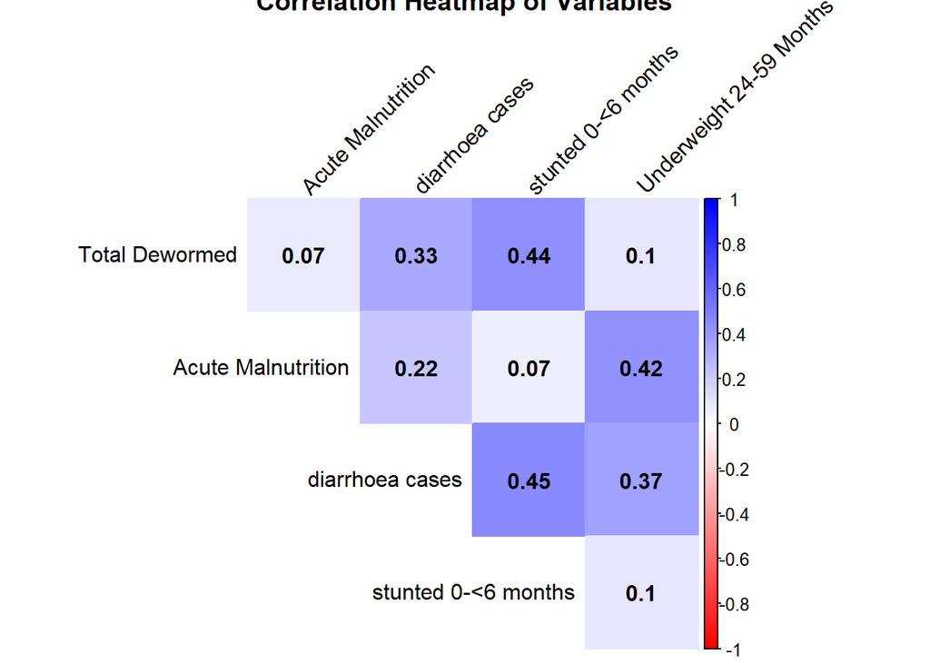

```r
# Create a correlation plot (heatmap)
corrplot(correlation_matrix, method = "color", type = "upper",
         tl.col = "black",
         tl.srt = 45,
         diag = FALSE,
         addCoef.col = "black",
         col = colorRampPalette(c("red", "white", "blue"))(200),
         title = "Correlation Heatmap of Variables")
```

```r
par(mar = c(1, 4, 2, 1))
```

Summary of correlations between 5 variables related to acute malnutrition among children under 5 years across different counties in Kenya from January 2021 to June 2023:

Overall, these correlations suggest potential associations and interactions between the variables, which could help identify patterns and trends related to acute malnutrition and related health issues in different counties.

# Data Interpretation and Conclusion:

1.Descriptive Statistics: The descriptive statistics provide insights into the data’s characteristics. The dataset contains information on the total number of children dewormed, acute malnutrition cases, stunted and underweight children across Kenya’s counties from January 2021 to June 2023. There are some missing values in the ‘Acute Malnutrition’ column, totaling 355 values. The maximum number of children dewormed during the study period was 392,800. The average number of acute malnutrition cases per month was approximately 125.4, with some counties experiencing outliers, reporting as high as 4123.0 cases in a single month.

3.Time Series Analysis: The time series analysis reveals an overall upward trend in acute malnutrition cases over time, particularly between 2021 and 2023. There were large fluctuations in 2022 and 2023, indicating high variability in acute malnutrition cases. This finding highlights the importance of understanding the underlying factors driving these fluctuations and addressing them through timely interventions.

4.Statistical Significance of Variability (ANOVA): The ANOVA results show significant variations in acute malnutrition cases across different years from January 2021 to June 2023. The rejection of the null hypothesis suggests that there is a statistical difference in acute malnutrition cases between the years, implying a need for targeted interventions based on year-specific trends.

5.Inferential Analysis: The inability to compute the p-value for the inferential analysis may be attributed to perfect collinearity between the “mean_prevalence_rate” and “county” variables. While further investigation is required, the identified upward trend and county-level variations in acute malnutrition cases provide valuable information for public health interventions.

6.Correlation Analysis: The correlation analysis shows weak to moderate positive correlations between the total number of children dewormed, acute malnutrition cases, diarrhoea cases, stunted 0-<6 months, and underweight 24-59 months. These associations suggest potential interactions between these variables and provide insights into the complex interplay of factors contributing to acute malnutrition in different counties.

#Analysis done by; THOMAS MABELE MASIBO, +254798615674, masibonbci@gmail.com